# Analysis

Varsha Ujjinni Vijay Kumar

27/06/2021

```r
data <- read_dta("C_TestingData.dta")
```

## 0.1 About the data

This data set is a result of a depression questionnaire given to the recruited patients in two different locations Tin Shui Wai and Sham Shui Po, which was followed up three different times of age. The depression index is indicated by `phq` (total score oh PHQ-9) in the data set and is abbreviated to be `PHQ-9` and stressful life events index is indicated by `sle` (total stress life events in the past year) in the data set and is abbreviated to be `SLE`.

Let us have a glimpse of how the data set is given: The following table is a data table made using the DT package in R. The table contains columns such as ID, sex, age, SLE and PHQ from the questionnaires. The data set has values from 3 different waves at different intervals of time.

```r
data %>%
  filter(source == 3) %>%
  select(ID,sex,age,sle,phq) %>%
  DT::datatable(colnames = c('Patient ID', 'Gender', 'Age', 'stressful life events index', 'Depression index'))
```

|  | Patient ID | Gender | Age | stressful life events index | Depression index |
| --- | --- | --- | --- | --- | --- |
| 1 | 244 | 1 | 53 | 1 | 1 |
| 2 | 709 | 1 | 81 | 0 | 2 |
| 3 | 760 | 0 | 86 | 4 | 9 |
| 4 | 3246 | 0 | 65 | 0 | 0 |
| 5 | 1144 | 1 | 59 | 0 | 7 |
| 6 | 3033 | 0 | 38 | 0 | 0 |
| 7 | 2363 | 1 | 67 | 0 | 9 |
| 8 | 1724 | 1 | 35 | 0 | 5 |
| 9 | 2940 | 1 | 58 | 0 | 0 |
| 10 | 163 | 0 | 53 | 0 | 4 |

[output cut: 1149 more lines]

## 0.2 Distribution Analysis

Now if we were to look at the distribution of the two genders for both SLE and PHQ individually.

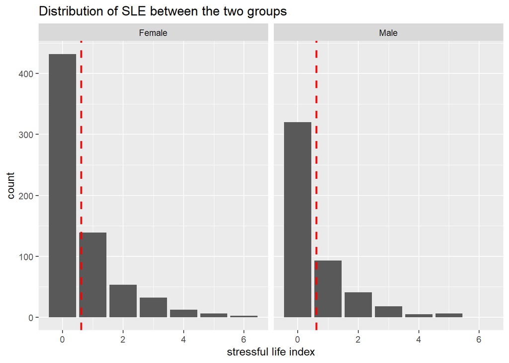

```r
data %>%
  filter(source == 3)%>%
  mutate(gender = case_when(sex == 0 ~ "Male",
                            sex == 1 ~"Female")) %>%
  select(gender,sle,phq) %>%
  ggplot(aes(x = sle)) +
  geom_bar() +
  geom_vline(aes(xintercept = mean(sle)),color = "red",linetype = "dashed",size = 0.9)+
  facet_wrap(~ gender)+
    theme(legend.position = "none") +
  labs(x = "stressful life index",title = "Distribution of SLE between the two groups")
```

From the plot above, it can be observed that there are number of females who are having more stressful life events than when compared to that of the males. There are observations in the female grid that the values for a few questions is around 6. both these graphs are right-skewed.

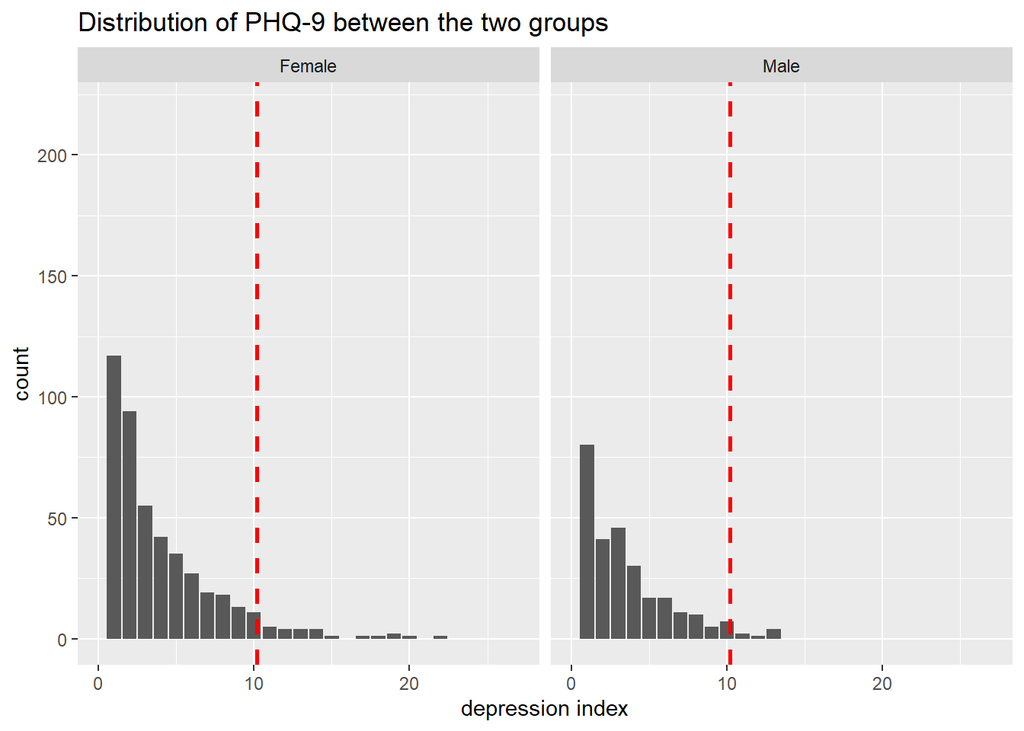

```r
data %>%
  filter(source == 3)%>%
  mutate(gender = case_when(sex == 0 ~ "Male",
                            sex == 1 ~"Female")) %>%
  select(gender,sle,phq) %>%
  ggplot(aes(x = phq)) +
  geom_bar() +
  scale_x_continuous(limits = c(0,27)) +
  facet_wrap(~ gender)+
  geom_vline(aes(xintercept = mean(phq)),color = "red",linetype = "dashed",size = 0.9) +
  labs(x = "depression index",title = "Distribution of PHQ-9 between the two groups")
```

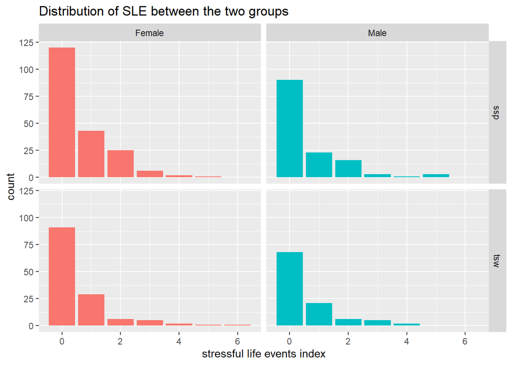

```r
data %>%
  filter(filter == c("tsw","ssp")) %>%
  select(filter,sex,phq,sle,source) %>%
  filter(source == 3)%>%
  mutate(gender = case_when(sex == 0 ~ "Male",
                            sex == 1 ~"Female")) %>%
  ggplot(aes(x = sle,fill = gender)) +
  geom_bar() +
  facet_grid(filter ~ gender)+
  theme(legend.position = "none")+
  labs(x = "stressful life events index",
       title = "Distribution of SLE between the two groups")
```

The above graph depicts the bar graphs which shows SLE faceted for the gender and also the places (TSW and SSP), it can be seen that in both the places:

- The female patients have a higher number of values when compared to that of the male gender.
- Between TSW and SSP, the patients at TSW are more inclined towards stressful life events in case of females and more number of males have indicated to have higher amount of stressful life events in SSP.

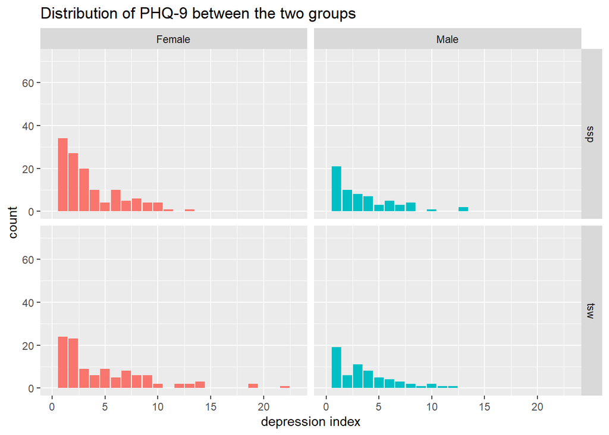

```r
data %>%
  filter(filter == c("tsw","ssp")) %>%
  select(filter,sex,phq,sle,source) %>%
  filter(source == 3)%>%
  mutate(gender = case_when(sex == 0 ~ "Male",
                            sex == 1 ~"Female")) %>%
  ggplot(aes(x = phq,fill = gender)) +
  geom_bar() +
  facet_grid(filter ~ gender)+
  scale_x_continuous(limits = c(0,23))+
  theme(legend.position = "none")+
  labs(x = "depression index",
       title = "Distribution of PHQ-9 between the two groups")
```

From the above two facted bar graphs, it can be inferred in a way that the stressful life events, are somehow inter-related to the depression index. Meaning that the people who have a higher index of stressful life events are more likely to have a higher range of depression index.

This is however in the case of a general overview in between genders.

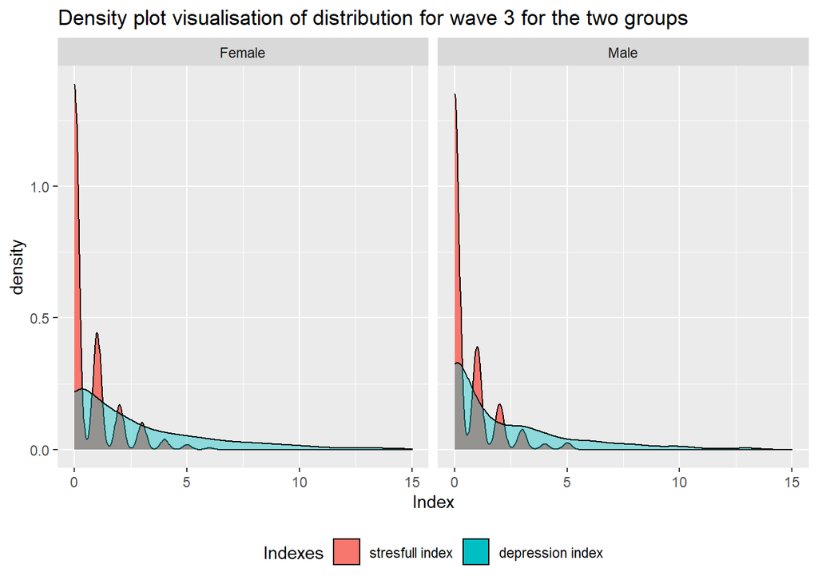

```r
data %>%
  filter(source == 3)%>%
  mutate(gender = case_when(sex == 0 ~ "Male",
                            sex == 1 ~"Female")) %>%
  select(gender,sle,phq) %>%
  ggplot(aes(y = ..density..)) +
  geom_density(aes(x = sle,
                   fill = "blue"))+
  geom_density(aes(x = phq,
                   fill = "red"),
               alpha = 0.4)+
  scale_x_continuous(limits = c(0,15))+
  facet_wrap(~ gender) +
  labs(title = "Density plot visualisation of distribution for wave 3 for the two groups",
       x = "Index")+
  theme(legend.position = "bottom")+
  scale_fill_discrete(name = "Indexes",
                      labels = c("stresfull index","depression index"))
```

## 0.3 Regression Analysis

Coming to make models for the data, let us have a look at the linear regression of the two groups with age and sex as their predictor variables in Wave 3.

```r
wave3 <- data %>%  filter(source == 3)
fit_sle <- lm(sle ~ age + sex, wave3)
summary(fit_sle)
```

```
##
## Call:
## lm(formula = sle ~ age + sex, data = wave3)
##
## Residuals:
##     Min      1Q  Median      3Q     Max
## -0.6762 -0.6280 -0.5771  0.3793  5.3810
##
## Coefficients:
##              Estimate Std. Error t value Pr(>|t|)
## (Intercept)  0.638774   0.114045   5.601 2.66e-08 ***
## age         -0.001121   0.001901  -0.590    0.555
## sex          0.057649   0.062461   0.923    0.356
## ---
## Signif. codes:  0 '***' 0.001 '**' 0.01 '*' 0.05 '.' 0.1 ' ' 1
##
## Residual standard error: 1.046 on 1156 degrees of freedom
## Multiple R-squared:  0.001099,   Adjusted R-squared:  -0.0006288
## F-statistic: 0.6361 on 2 and 1156 DF,  p-value: 0.5295
```

In wave 3 , the above summary can be interpreted as:

- The model `sle ~ age+sex`, has a p-value of 0.5295, which says that the age and sex does not influence the values of stressful events of a persons life.Or tells us that they are not the only predictors.
- The minimum residual value for SLE is -0.6, median residual is -0.5 and the maximum residual is 5.38.
- It also shows the Residual std error is 1.046 which is a considerably low value which is not completely low but tells us that it could be a good fit, but not the best.

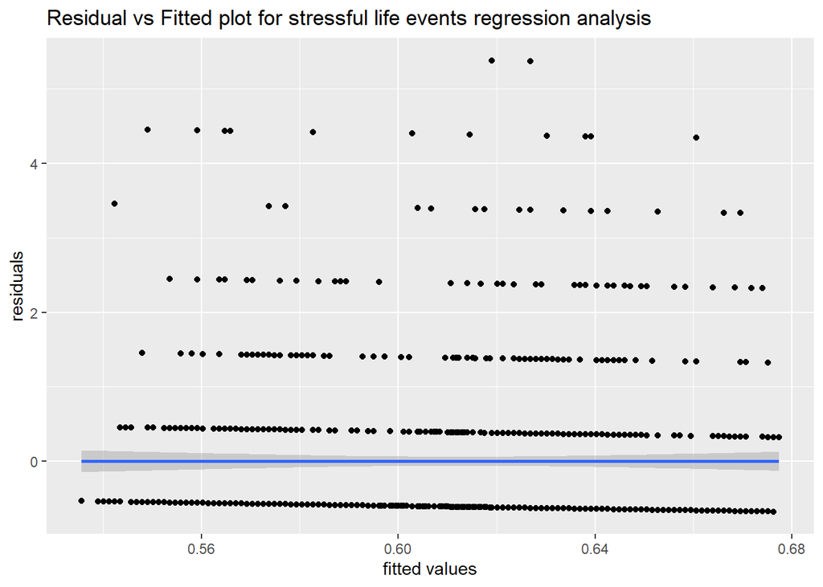

```r
ggplot(fit_sle,aes(x = .fitted, y = .resid)) +
  geom_point() +
  geom_smooth(method = "lm")+
  labs(x = "fitted values", y = "residuals", title = "Residual vs Fitted plot for stressful life events regression analysis")
```

The above graph shows the residual graph for `fit_sle`, as can be seen the model does not fir the data as well. As most of the points are away from the middle blue line.

```r
fit_phq <- lm(phq ~ age + sex, wave3)
summary(fit_phq)
```

```
##
## Call:
## lm(formula = phq ~ age + sex, data = wave3)
##
## Residuals:
##    Min     1Q Median     3Q    Max
##  -48.5  -20.3   -9.5    2.6 8944.4
##
## Coefficients:
##             Estimate Std. Error t value Pr(>|t|)
## (Intercept) -49.2362    28.7463  -1.713   0.0870 .
## age           0.9398     0.4792   1.961   0.0501 .
## sex          15.9497    15.7441   1.013   0.3112
## ---
## Signif. codes:  0 '***' 0.001 '**' 0.01 '*' 0.05 '.' 0.1 ' ' 1
##
## Residual standard error: 263.7 on 1156 degrees of freedom
## Multiple R-squared:  0.004002,   Adjusted R-squared:  0.002279
## F-statistic: 2.322 on 2 and 1156 DF,  p-value: 0.0985
```

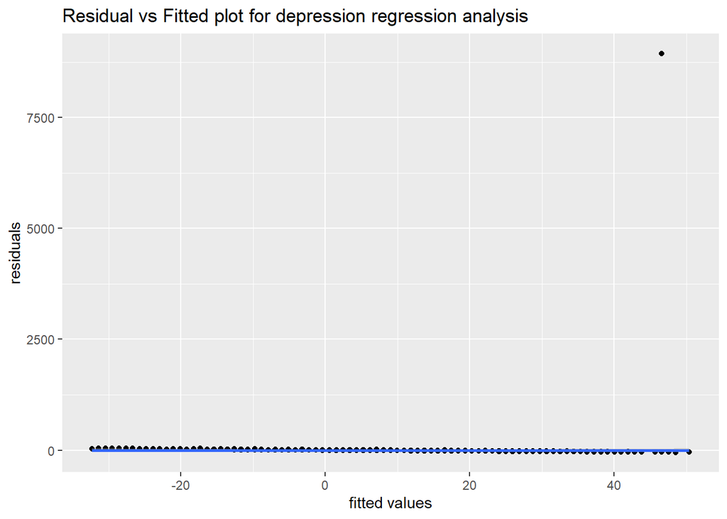

```r
ggplot(fit_phq,aes(x = .fitted, y = .resid)) +
  geom_point() +
  geom_smooth(method = "lm")+
  labs(x = "fitted values", y = "residuals", title = "Residual vs Fitted plot for depression regression analysis")
```

```r
w1_sle <- data %>% filter(source == 1)
summary(lm(sle ~ sex + age, data = w1_sle))
```

```
##
## Call:
## lm(formula = sle ~ sex + age, data = w1_sle)
##
## Residuals:
##     Min      1Q  Median      3Q     Max
## -0.8230 -0.6749 -0.5785  0.3463  7.4850
##
## Coefficients:
##             Estimate Std. Error t value Pr(>|t|)
## (Intercept) 0.405687   0.116026   3.497  0.00049 ***
## sex         0.128146   0.066053   1.940  0.05263 .
## age         0.003527   0.002128   1.657  0.09779 .
## ---
## Signif. codes:  0 '***' 0.001 '**' 0.01 '*' 0.05 '.' 0.1 ' ' 1
##
## Residual standard error: 1.085 on 1110 degrees of freedom
##   (1 observation deleted due to missingness)
## Multiple R-squared:  0.005441,   Adjusted R-squared:  0.003649
## F-statistic: 3.037 on 2 and 1110 DF,  p-value: 0.0484
```

```r
w2_sle <- data %>% filter(source == 2)
summary(lm(sle ~ age + sex, data = w2_sle))
```

```
##
## Call:
## lm(formula = sle ~ age + sex, data = w2_sle)
##
## Residuals:
##     Min      1Q  Median      3Q     Max
## -0.6365 -0.6127 -0.5617  0.4270  8.4422
##
## Coefficients:
##               Estimate Std. Error t value Pr(>|t|)
## (Intercept)  0.6428092  0.1100906   5.839 6.86e-09 ***
## age         -0.0003963  0.0019569  -0.203    0.840
## sex         -0.0596595  0.0617942  -0.965    0.335
## ---
## Signif. codes:  0 '***' 0.001 '**' 0.01 '*' 0.05 '.' 0.1 ' ' 1
##
## Residual standard error: 1.025 on 1132 degrees of freedom
##   (1 observation deleted due to missingness)
## Multiple R-squared:  0.0008394,  Adjusted R-squared:  -0.0009259
## F-statistic: 0.4755 on 2 and 1132 DF,  p-value: 0.6217
```

```r
w1_phq <- data %>% filter(source == 1)
summary(lm(phq ~ sex + age, data = w1_phq))
```

```
##
## Call:
## lm(formula = phq ~ sex + age, data = w1_phq)
##
## Residuals:
##     Min      1Q  Median      3Q     Max
## -2.4423 -1.6107 -1.1357  0.7553 21.9398
##
## Coefficients:
##             Estimate Std. Error t value Pr(>|t|)
## (Intercept) 0.985413   0.305134   3.229  0.00128 **
## sex         0.762087   0.173658   4.388 1.25e-05 ***
## age         0.008685   0.005597   1.552  0.12100
## ---
## Signif. codes:  0 '***' 0.001 '**' 0.01 '*' 0.05 '.' 0.1 ' ' 1
##
## Residual standard error: 2.853 on 1111 degrees of freedom
## Multiple R-squared:  0.01836,    Adjusted R-squared:  0.0166
## F-statistic: 10.39 on 2 and 1111 DF,  p-value: 3.38e-05
```

```r
w2_phq <- data %>% filter(source == 2)
summary(lm(phq ~ sex + age, data = w2_phq))
```

```
##
## Call:
## lm(formula = phq ~ sex + age, data = w2_phq)
##
## Residuals:
##     Min      1Q  Median      3Q     Max
## -1.6763 -1.4824 -1.0280  0.7791 16.9526
##
## Coefficients:
##              Estimate Std. Error t value Pr(>|t|)
## (Intercept)  1.291609   0.232896   5.546 3.64e-08 ***
## sex          0.446669   0.130686   3.418 0.000654 ***
## age         -0.003877   0.004140  -0.936 0.349254
## ---
## Signif. codes:  0 '***' 0.001 '**' 0.01 '*' 0.05 '.' 0.1 ' ' 1
##
## Residual standard error: 2.169 on 1133 degrees of freedom
## Multiple R-squared:  0.01139,    Adjusted R-squared:  0.009645
## F-statistic: 6.527 on 2 and 1133 DF,  p-value: 0.001519
```

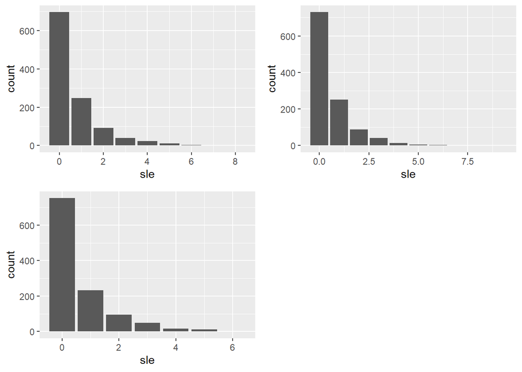

Figure 1: Stressful index for waves 1-3

```r
p1 <- data %>%  filter(source == 1) %>% ggplot(aes(x = sle)) +
  geom_bar()
p2 <- data %>%  filter(source == 2) %>% ggplot(aes(x = sle)) +
  geom_bar()
p3 <- data %>%  filter(source == 3) %>% ggplot(aes(x = sle)) +
  geom_bar()

ggpubr::ggarrange(p1, p2, p3)
```

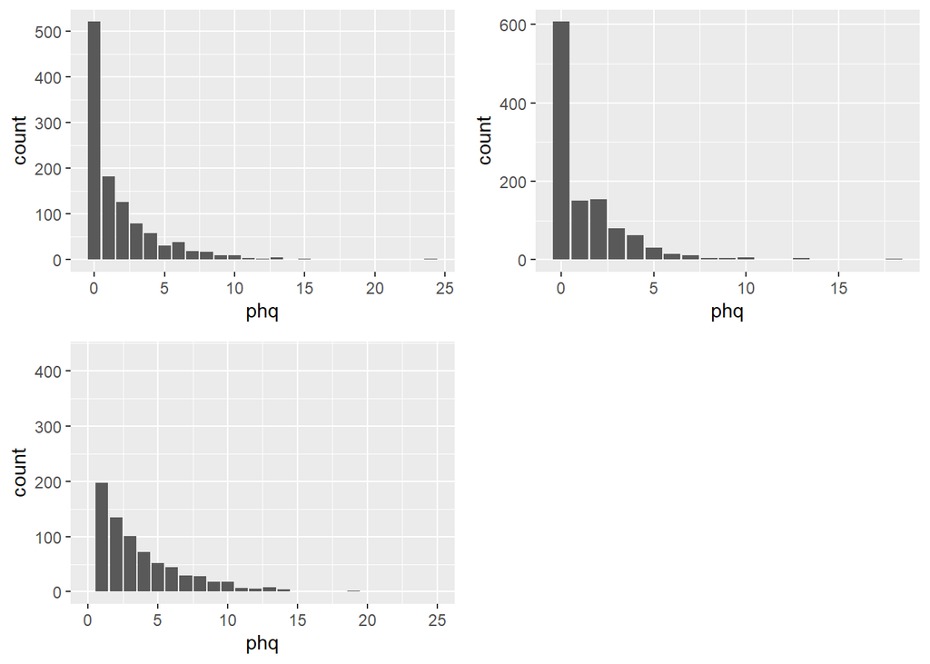

Figure 2: Depression index for waves 1-3

```r
p4 <- data %>%  filter(source == 1) %>% ggplot(aes(x = phq)) +
  geom_bar()
p5 <- data %>%  filter(source == 2) %>% ggplot(aes(x = phq)) +
  geom_bar()
p6 <- data %>%  filter(source == 3) %>% ggplot(aes(x = phq)) +
  geom_bar()+
  scale_x_continuous(limits = c(0,25))

ggpubr::ggarrange(p4, p5, p6)
```

## 0.4 Summary

The predictor variables sex and age are not the only variables for checking the stressful life events index and the depression index, there are better models that can be built with other predictor variables.

## 0.5 References

- Wickham et al., (2019). Welcome to the tidyverse. Journal of Open Source Software, 4(43), 1686, https://doi.org/10.21105/joss.01686
- Hadley Wickham and Evan Miller (2020). haven: Import and Export ‘SPSS’, ‘Stata’ and ‘SAS’ Files. R package version 2.3.1. https://CRAN.R-project.org/package=haven
- Simon Garnier (2018). viridis: Default Color Maps from ‘matplotlib’. R package version 0.5.1. https://CRAN.R-project.org/package=viridis

-David Robinson, Alex Hayes and Simon Couch (2021). broom: Convert Statistical Objects into Tidy Tibbles. R package version 0.7.5. https://CRAN.R-project.org/package=broom

- Hao Zhu (2021). kableExtra: Construct Complex Table with ‘kable’ and Pipe Syntax. R package version 1.3.4. https://CRAN.R-project.org/package=kableExtra